## Majed’s mice: Impact of iron deficiency on ferritin concentration

### Overview of data

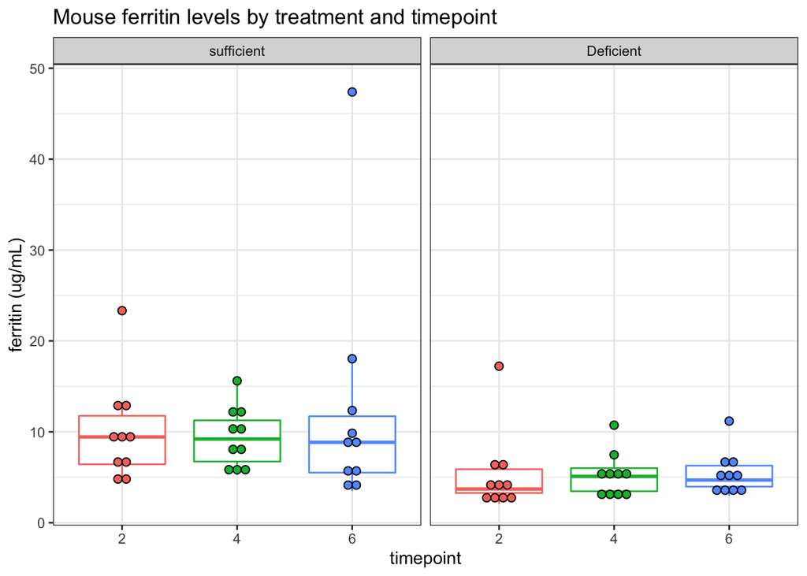

Looking at this plot, it looks like the treatment had an effect on ferritin levels, but the ferritin levels did not differ across timepoints within a treatment group.

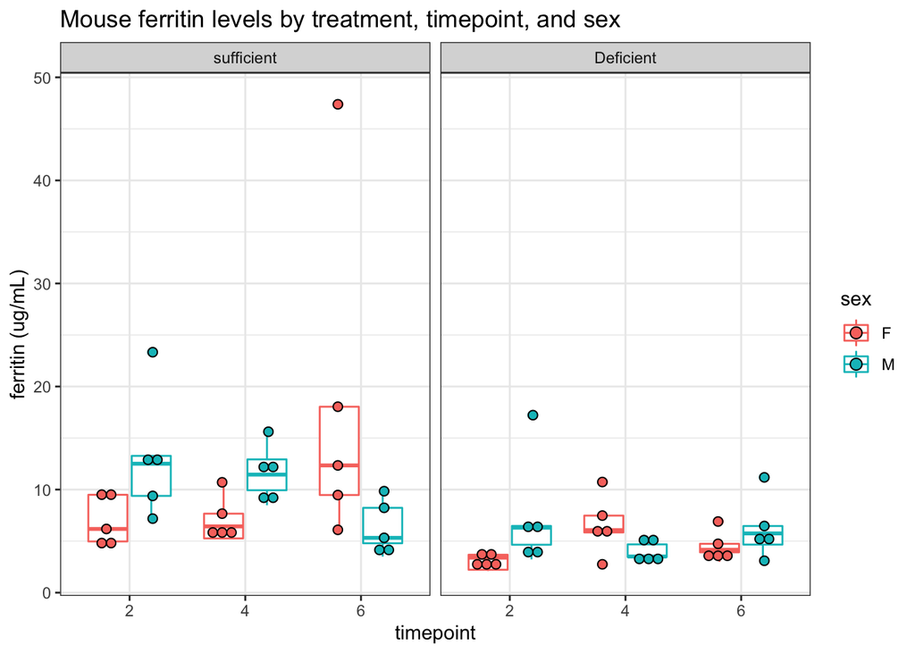

When the data are further broken down by sex, it looks like there are sex-specific differences in ferritin levels depending on the treatment/timepoint. We will explore this through the multivariate analysis.

### Box Cox Transformation to normality

#### Test data for normality

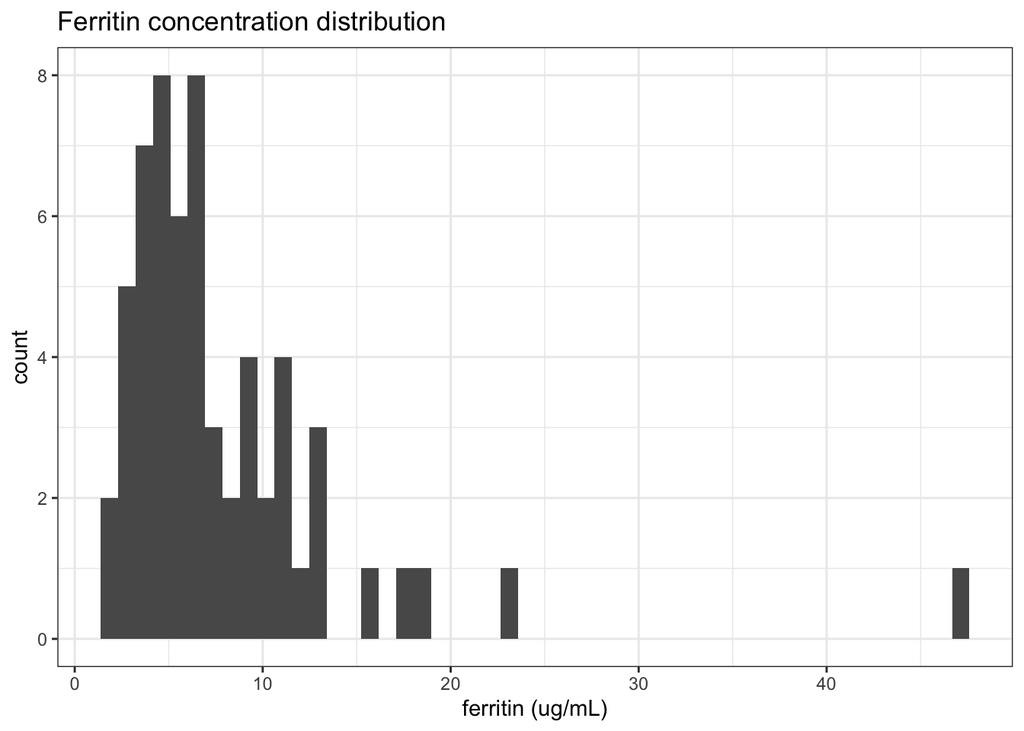

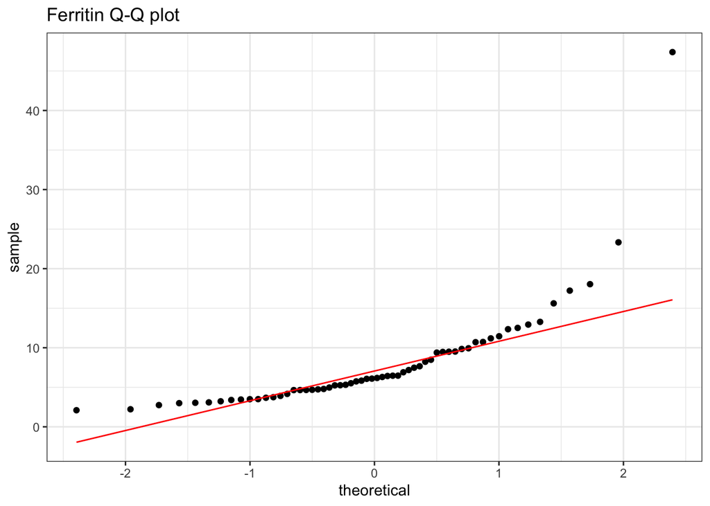

```
    Shapiro-Wilk normality test

data:  df_mice$`ferritin (ug/mL)`
W = 0.64814, p-value = 1.003e-10
```

In the Shapiro-Wilk test, a p-value less than 0.05 indicates the data are not normal. As such, both the plots and the test indicate that our data are non-normal. In order to run the multivariate analysis, we need to transform the data to fit the normality assumption.

#### Box-Cox transformation

The Box Cox transformation transforms non-normal data according to the following equation:

y(lambda) = (y^lambda - 1)/lambda; if lambda != 0

The algorithm will find the “optimal value” for lambda - the one which results in the best approximation of a normal distribution curve.

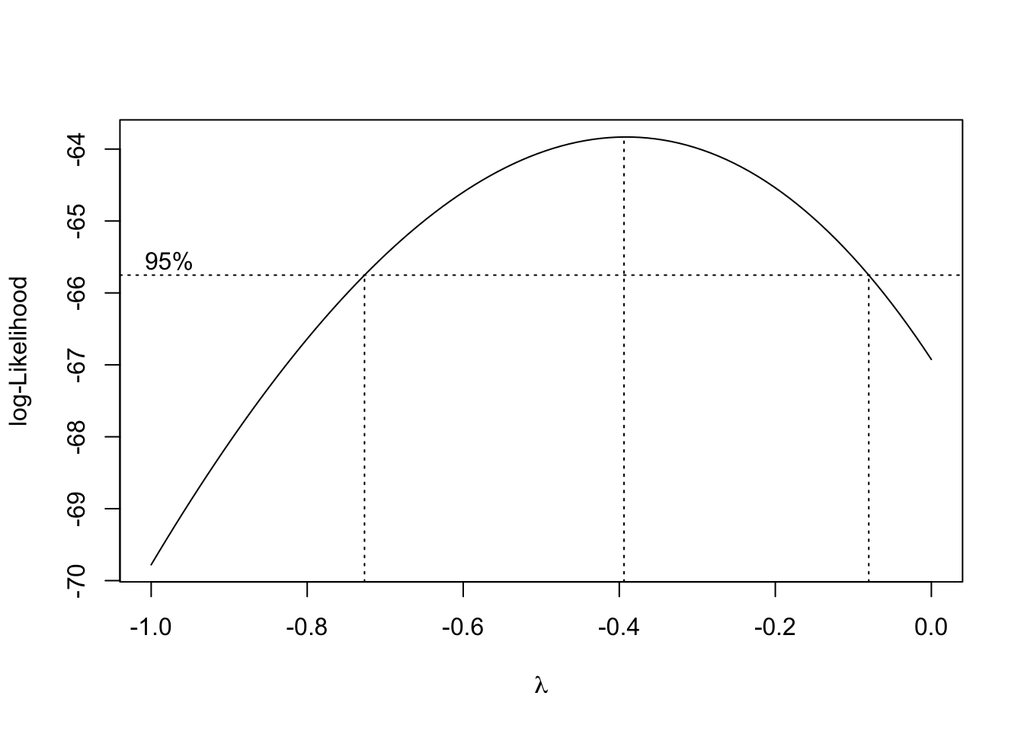

Plotted is the log-likelihood as a function of possible lambda values. The dashed lines indicate both the value that maximizes the log-likelihood and the associated confidence interval. Lambda = -0.4 suggests a transformation of the form (y^-0.4 - 1)/-0.4 is optimal.

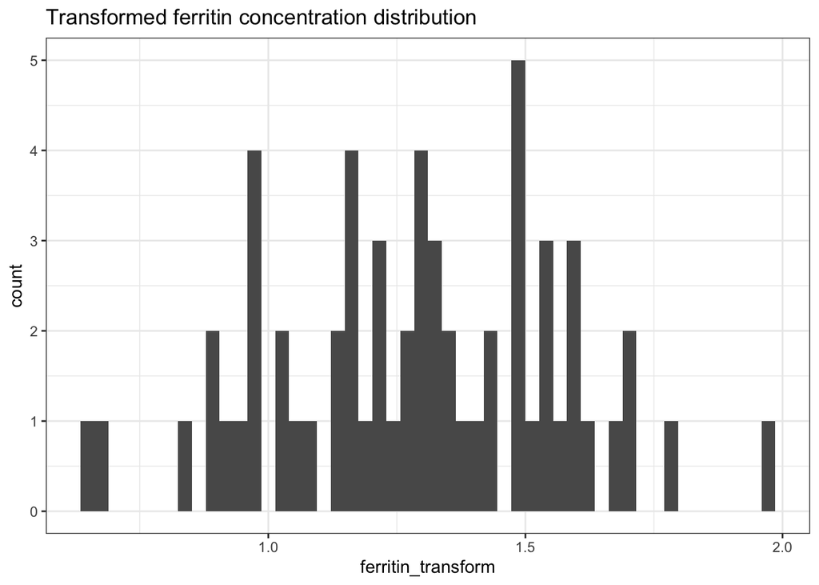

We can see here a more normal distribution. I used these transformed data (ferritin_transform) for the multivariate analysis.

### Multivariate analysis

*Note: I didn’t remove any apparent outliers (notably F D6 sufficient) for this analysis.

When building these models, you can choose to start top-down with a lot of terms and their interactions and take out the non-significant variables, or you can start from the bottom-up and add in variables. In this case, I started with the most complex model (though this is rarely the best) and planned to cut terms out -

(“:” indicates an interaction term)

```
                        Df Sum Sq Mean Sq F value   Pr(>F)
sex                      1 0.0860  0.0860   2.202  0.14434
timepoint                2 0.0236  0.0118   0.303  0.74033
treatment                1 1.4086  1.4086  36.060 2.46e-07 ***
sex:timepoint            2 0.5219  0.2610   6.681  0.00276 **
sex:treatment            1 0.0191  0.0191   0.489  0.48775
timepoint:treatment      2 0.0317  0.0158   0.405  0.66891
sex:timepoint:treatment  2 0.5333  0.2666   6.826  0.00246 **
Residuals               48 1.8750  0.0391
---
Signif. codes:  0 '***' 0.001 '**' 0.01 '*' 0.05 '.' 0.1 ' ' 1
```

**treatment**

```
# A tibble: 1 x 2
  comparison                 p.adj
  <chr>                      <dbl>
1 Deficient-sufficient 0.000000246
```

Treatment had a highly significant effect on ferritin concentration, regardless of timepoint or sex.

**sex:timepoint**

```
# A tibble: 2 x 2
  comparison   p.adj
  <chr>        <dbl>
1 M:2-F:2    0.00608
2 F:6-F:2    0.0480
```

The sex:timepoint interaction term is significant because males and females, though not significantly different overall, were significantly different on day 2. Additionally, females had significantly different ferritin levels on day 6 compared to day 2, regardless of treatment.

**sex:timepoint:treatment**

```
# A tibble: 11 x 2
   comparison                       p.adj
   <chr>                            <dbl>
 1 F:2:Deficient-F:2:sufficient 0.0308
 2 F:2:Deficient-M:2:sufficient 0.0000597
 3 M:4:Deficient-M:2:sufficient 0.00701
 4 F:6:Deficient-M:2:sufficient 0.0254
 5 F:2:Deficient-F:4:sufficient 0.0229
 6 F:2:Deficient-M:4:sufficient 0.0000873
 7 M:4:Deficient-M:4:sufficient 0.00975
 8 F:6:Deficient-M:4:sufficient 0.0343
 9 F:2:Deficient-F:6:sufficient 0.0000199
10 M:4:Deficient-F:6:sufficient 0.00264
11 F:6:Deficient-F:6:sufficient 0.0103
```

Though a lot of these terms aren’t very interesting, we can see here that treatment had an especially significant effect in females on days 2 and 6 (rows 1 and 11) and in males on day 4 (row 7).

#### Plots

Based on these results, sex, treatment, and timepoint day all had an effect on ferritin levels. Below are plots that incorporate all three variables so you can visualize these differences. I show a couple different iterations of the same plot, depending on what interaction you are most interested in looking at.

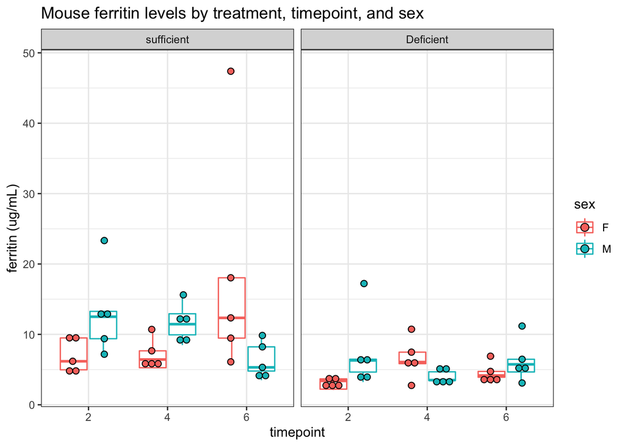

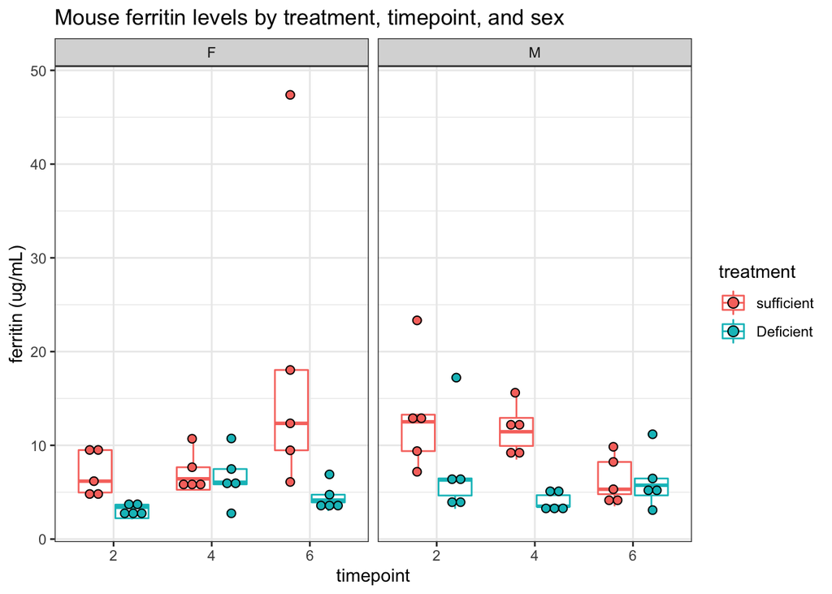

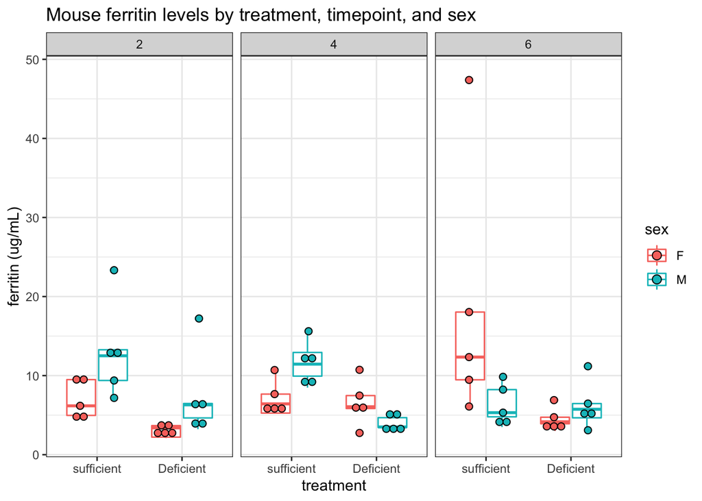

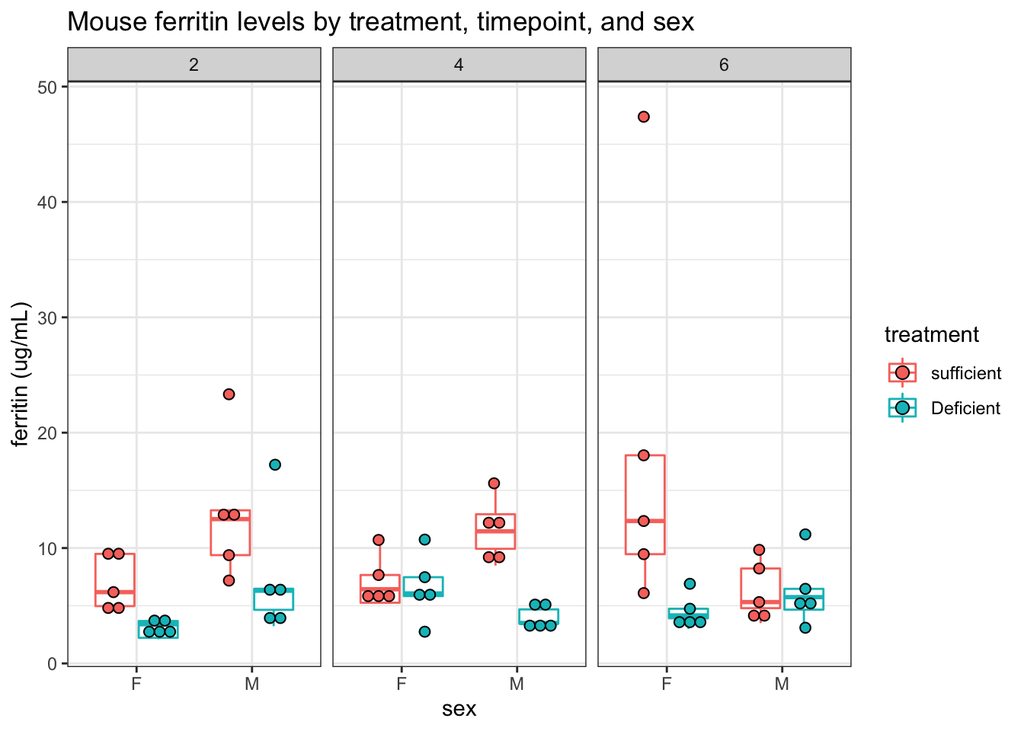

Hope this helps, let me know if you have any questions and/or suggestions. I know I threw a lot of plots in at the end, so let me know which one you think best displays the data and the interactions reported in the multivariate analysis and we can improve on it :)